# Homework 2

Johann Memmel

January 20, 2020

# Homework 2

## Scenario 1

```r
data1 = read.csv("Homework 2 Scenario 1.csv")
```

The null hypothesis is that the mean level of shrimp caught in 2009 and 2010 will be the same. The alternative hypothesis is that there will be a change in shrimp caught between the two years.

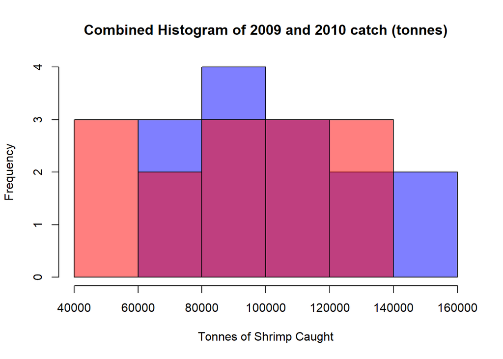

```r
hist(data1$X2009.catch..tonnes., col = rgb(0,0,1,1/2), breaks = 6, xlim = c(40000, 160000), main = "Combined Histogram of 2009 and 2010 catch (tonnes)", xlab = "Tonnes of Shrimp Caught")
hist(data1$X2010.catch..tonnes., add=T, col = rgb(1,0,0,1/2), breaks = 6)
```

With the 2009 results in blue and the 2010 results in red

An independent two sample T test is the correct type of test to use because the goal is to determine if there is a difference between two groups means.

```r
t.test(data1$X2010.catch..tonnes., data1$X2009.catch..tonnes.)
```

```
##
##  Welch Two Sample t-test
##
## data:  data1$X2010.catch..tonnes. and data1$X2009.catch..tonnes.
## t = -1.2099, df = 25.413, p-value = 0.2374
## alternative hypothesis: true difference in means is not equal to 0
## 95 percent confidence interval:
##  -36267.967   9410.825
## sample estimates:
## mean of x mean of y
##  91728.57 105157.14
```

```r
qt(0.95,13)
```

```
## [1] 1.770933
```

The results show that p>0.05 so we can not reject the nulll hypothesis. Then the t observed (-1.2099) is closer to zero than the t critical (1.7709) indicating that there is not a significant diferance.

The conclusion I would draw is that the null hypothesis cannot be rejected.

## Scenario 2

```r
data2 = read.csv("Homework 2 Scenario 2.csv")
```

The null hypothesis is that the phosphorous levels are less than the maximum stated in the guildlines. The alternative hypothesis is that phosphorous levels are higher than the guildlines allow.

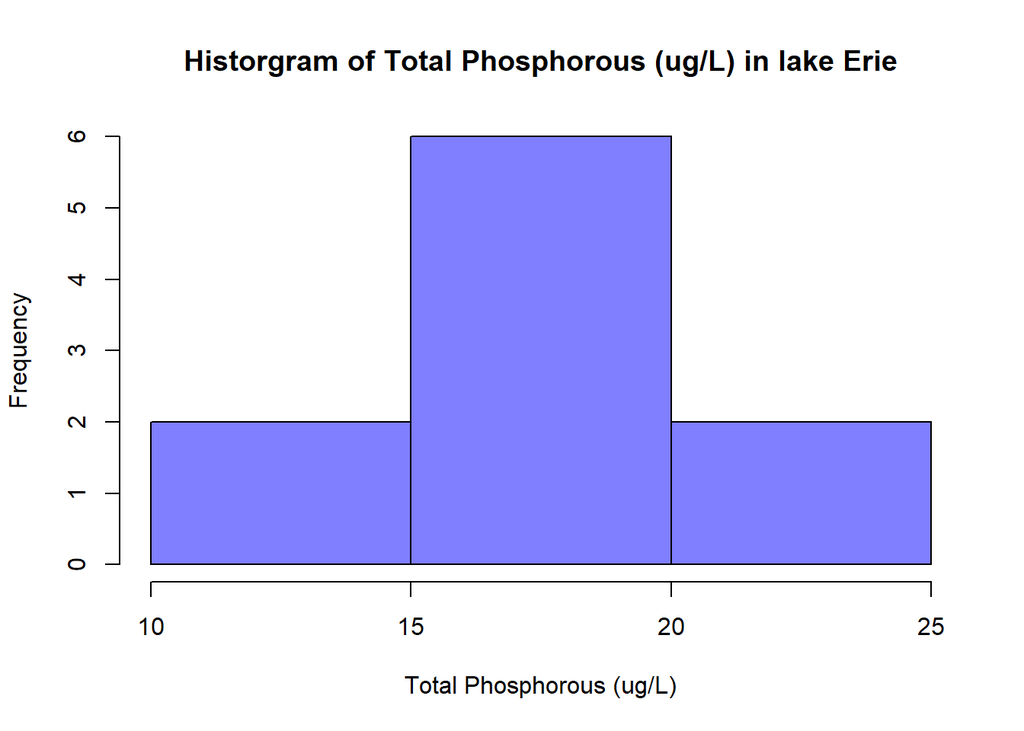

```r
hist(data2$Total.phosphorous..ug.L., col = rgb(0,0,1,1/2), breaks = 4, xlab = "Total Phosphorous (ug/L)", main = "Historgram of Total Phosphorous (ug/L) in lake Erie")
```

A one-tailed one sample t-test is the correct test for this dataset because we are compairing to a single known value, hence one sample, and a one-tailed due to only being interesting in if the values are larger than the known value.

```r
t.test(data2$Total.phosphorous..ug.L., mu=15, alternative = "greater")
```

```
##
##  One Sample t-test
##
## data:  data2$Total.phosphorous..ug.L.
## t = 1.8462, df = 9, p-value = 0.04897
## alternative hypothesis: true mean is greater than 15
## 95 percent confidence interval:
##  15.01658      Inf
## sample estimates:
## mean of x
##     17.34
```

```r
qt(0.95, 9)
```

```
## [1] 1.833113
```

The p-value of 0.04897 is below 0.05 and we therefore reject the null hypothesis. The t observed (1.8462) is also larger that the t critical (1.833113) indicating that there is a significant difference.

Based on these results I would reject the null hypothesis.

## Scenario 3

```r
data3 = read.csv("Homework 2 Scenario 3.csv")
```

The null hypothesis is that there will be no difference between the carnivorous and vegetarian groups. The alternative hypothesis is that there is a difference between the groups

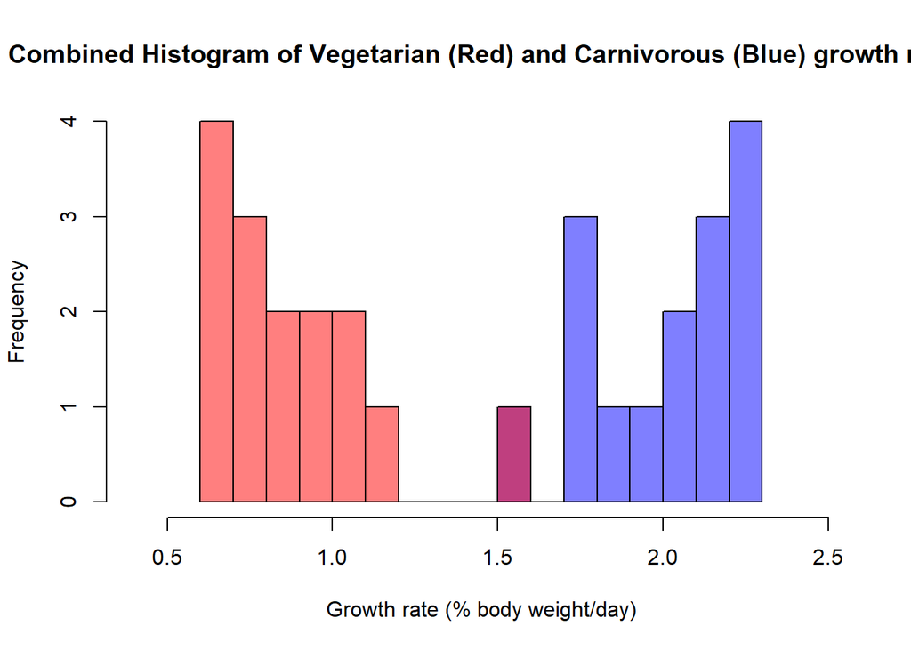

```r
hist(data3$Carnivorous, col = rgb(0,0,1,1/2), breaks = 8, xlim = c(0.4, 2.5), main = "Combined Histogram of Vegetarian (Red) and Carnivorous (Blue) growth rate", xlab = "Growth rate (% body weight/day)")
hist(data3$Vegetarian, add=T, col = rgb(1,0,0,1/2), breaks = 8, xlim = c(0.6, 2.5))
```

An independent two sample T test is the correct type of test to use because the goal is to determine if there is a difference between two groups means.

```r
t.test(data3$Carnivorous, data3$Vegetarian)
```

```
##
##  Welch Two Sample t-test
##
## data:  data3$Carnivorous and data3$Vegetarian
## t = 12.237, df = 27.862, p-value = 1.008e-12
## alternative hypothesis: true difference in means is not equal to 0
## 95 percent confidence interval:
##  0.9435752 1.3230915
## sample estimates:
## mean of x mean of y
##  2.053333  0.920000
```

```r
qt(0.95,27.862)
```

```
## [1] 1.701419
```

The results show that p<0.05 so we reject the nulll hypothesis. Then the t observed (12.237)) is far larger than the t critical (1.7014) indicating that there is a significant diferance.

The conclusion I would draw is that the null hypothesis should be rejected.

## Scenario 4

```r
data4 = read.csv("Homework 2 Scenario 4v2.csv", fileEncoding="UTF-8-BOM", row.names = 1)
```

The null hypothesis is that the trophic level and outcomes are independent. The alternative hyptothesis is that the trophic levels and outcomes are not independent.

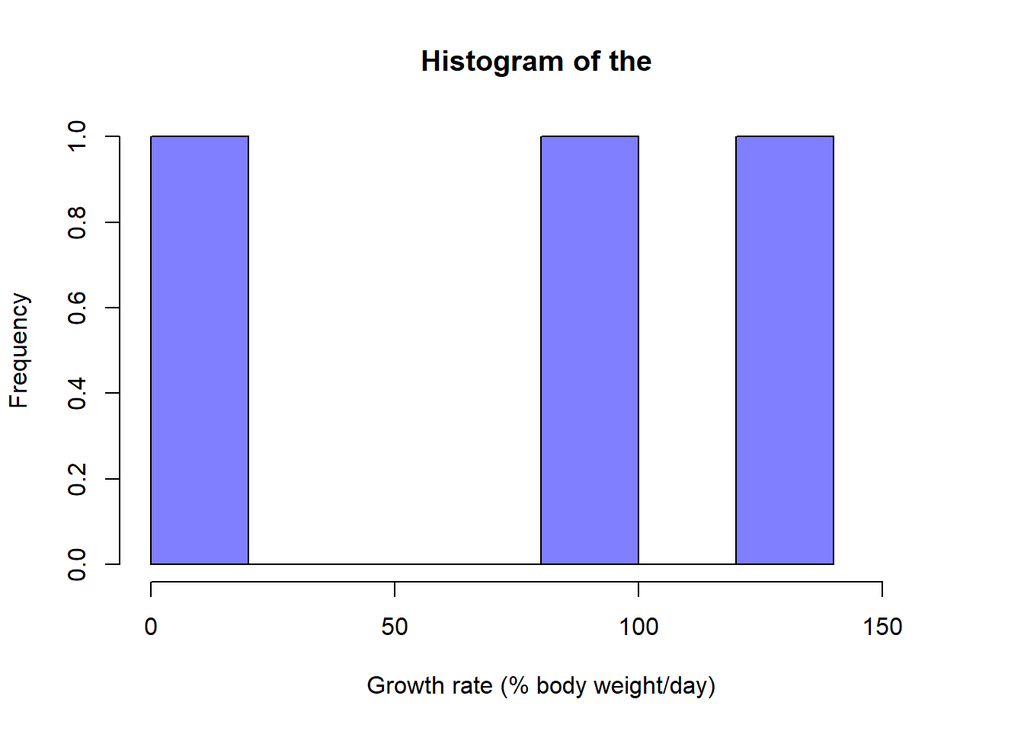

```r
hist(data4$X1st.Trophic.level, col = rgb(0,0,1,1/2), breaks = 5, xlim = c(0,160), main = "Histogram of the ", xlab = "Growth rate (% body weight/day)")
```

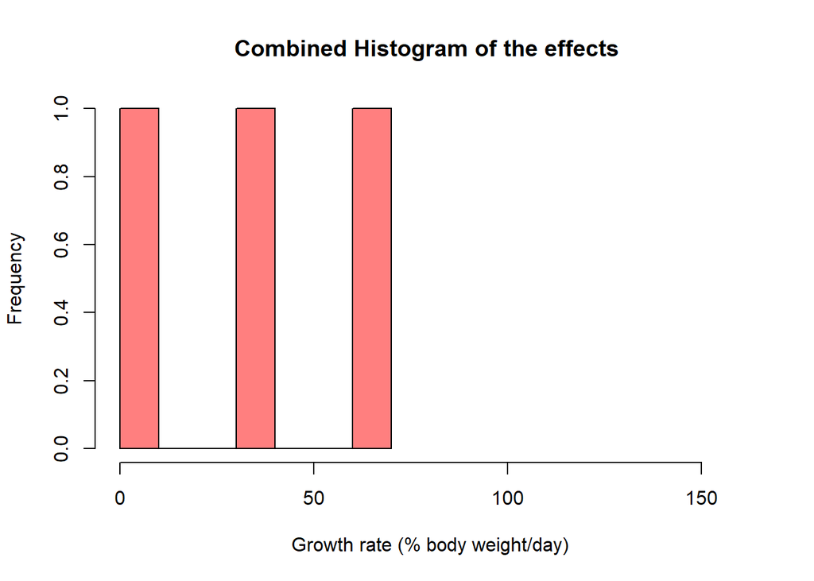

```r
hist(data4$Top.Predator, col = rgb(1,0,0,1/2), breaks = 5, xlim = c(0,160), main = "Combined Histogram of the effects ", xlab = "Growth rate (% body weight/day)")
```

This isn’t really histogramable data…

The type of test to that should be used is a chi-squared test because the data is categorical.

```r
chisq.test(data4)
```

```
##
##  Pearson's Chi-squared test
##
## data:  data4
## X-squared = 89.253, df = 2, p-value < 2.2e-16
```

Because the p-value is 2.2e-16 which is less that 0.05 we reject the null hypothesis.

Therefore we conclude that the trophic level and outcomes are not independent.